# Lesson 1: Visualization and Data Summarizing

Jeffrey Michler

2025-05-28

## Packages Used

A package is a collection of R functions and datasets designed to make certain tasks easier. You need to install and load a package before using it.

- `arrow` A package that allows R to read and write data in Parquet format, which is a fast and compact way to store data.
- `dplyr` A package for data manipulation. It helps you filter, group, summarize, and reshape data using clear, human-readable code.
- `ggplot2` A package for data visualization. It lets you make elegant, customizable charts and graphs.
- `tidyverse` A collection of packages (including dplyr, ggplot2, readr, and more) that work together and follow the same design philosophy for working with data.

## Learning Objectives

1. Understand the difference between files and objects
2. Modify data with good data hygiene practices
3. Summarize information from raw data
4. Visualize data to convey information

## Preparing the Workspace

We use **Projects** in RStudio to organize our work. A Project is essentially a folder that keeps everything (scripts, data, outputs) in one place.

To create a new project:  
- Go to `File > New Project`  
- Select `New Directory`  
- Choose `New Project` again  
- Name the directory (use short, informative names)

The **working directory** is the folder where R looks for files to read and where it saves output files.

An **object** is “container” in R that stores data, like a table or a list of numbers. For example: `merged_data` is an object containing the imported dataset.

A **data frame** is a spreadsheet-like table in R that holds data. It has rows (observations) and columns (variables).

To see your current working directory, use:

```r
getwd()
```

You can change your working directory using `setwd()`:

```r
setwd("path/to/your/folder")
```

For example:

```r
setwd("C:/Home/Github/GitHubFiles/equityag_materials")
```

Next, let’s create some folders to organize your files. A good file organization is essential for reproducibility and workflow.

```r
dir.create("data")    # Store all raw and cleaned datasets
dir.create("output")  # Save visualizations and reports here
```

`dir.create()` creates a new folder (directory). Useful for organizing your project (e.g., folders for data or outputs).

## Importing Data

There are many ways to import data into R. For this lesson, we’ll use the arrow package to read Parquet files.

Packages in R are collections of functions, code, and sometimes sample data, stored in libraries.

First, we load the package:

```r
library(arrow)
```

`library` loads a package you’ve already installed so you can use its tools/functions.

### Read the data:

Make sure the data file ‘merged_data.parquet’ is in the same folder as your R project directory.

This ensures R can find and read the data correctly without needing a full file path.

```r
merged_data <- read_parquet(file = "merged_data.parquet", stringsAsFactors = TRUE)
```

The function `read_parquet()` takes at least two arguments:

1. The file path to the dataset
2. How to handle text strings (`stringsAsFactors = TRUE` means treat text as categorical data)

The data from the file is now stored in an object called `merged_data`.

## Exploring the Data

Use the following functions to get a quick sense of the dataset:

```r
head(merged_data[, 1:10], 6) #show the first 6 rows, 10 first columns
```

```
##       geo2010 upward_mobility_rate_2010 upward_mobility_rate_2020
## 1 04001942600                 0.3555936                 0.3553644
## 2 04001942700                 1.0253210                 1.0253210
## 3 04001944000                 1.5812445                 1.5812777
## 4 04001944100                 0.5463194                 0.5464088
## 5 04001944201                 0.2962908                 0.2964045
## 6 04001944202                 0.2855063                 0.2854815
##         GEO_ID_2010SVI STATE_FIPS_2010SVI CNTY_FIPS_2010SVI TRACT_2010SVI
## 1 1400000US04001942600                  4                 1        942600
## 2 1400000US04001942700                  4                 1        942700
## 3 1400000US04001944000                  4                 1        944000
## 4 1400000US04001944100                  4                 1        944100
## 5 1400000US04001944201                  4                 1        944201
## 6 1400000US04001944202                  4                 1        944202
##   CENSUSAREA_2010SVI STCOFIPS_2010SVI      FIPS_x
## 1            588.707             4001 04001942600
## 2           1154.478             4001 04001942700
## 3            305.860             4001 04001944000
## 4            706.889             4001 04001944100
## 5            193.826             4001 04001944201
## 6            165.780             4001 04001944202
```

```r
tail(merged_data[, 1:10], 6) #show the last 6 rows, 10 first columns
```

```
##          geo2010 upward_mobility_rate_2010 upward_mobility_rate_2020
## 9617 41035970500                 1.8405927                 1.8406305
## 9618 41035970600                 1.4603699                 1.4565328
## 9619 41035970700                 1.5893507                 1.5913723
## 9620 41037960100                 0.9675313                 0.9674343
## 9621 41037960200                 0.9129945                 0.9129711
## 9622 49037942100                 0.3890071                 0.3890071
##      GEO_ID_2010SVI STATE_FIPS_2010SVI CNTY_FIPS_2010SVI TRACT_2010SVI
## 9617           <NA>                 NA                NA            NA
## 9618           <NA>                 NA                NA            NA
## 9619           <NA>                 NA                NA            NA
## 9620           <NA>                 NA                NA            NA
## 9621           <NA>                 NA                NA            NA
## 9622           <NA>                 NA                NA            NA
##      CENSUSAREA_2010SVI STCOFIPS_2010SVI FIPS_x
## 9617                 NA               NA   <NA>
## 9618                 NA               NA   <NA>
## 9619                 NA               NA   <NA>
## 9620                 NA               NA   <NA>
## 9621                 NA               NA   <NA>
## 9622                 NA               NA   <NA>
```

```r
str(merged_data[, 1:10]) #show structure and variable types, 10 first columns
```

```
## Classes 'tbl_df', 'tbl' and 'data.frame':    9622 obs. of  10 variables:
##  $ geo2010                  : chr  "04001942600" "04001942700" "04001944000" "04001944100" ...
##  $ upward_mobility_rate_2010: num  0.356 1.025 1.581 0.546 0.296 ...
##  $ upward_mobility_rate_2020: num  0.355 1.025 1.581 0.546 0.296 ...
##  $ GEO_ID_2010SVI           : chr  "1400000US04001942600" "1400000US04001942700" "1400000US04001944000" "1400000US04001944100" ...
##  $ STATE_FIPS_2010SVI       : num  4 4 4 4 4 4 4 4 4 4 ...
##  $ CNTY_FIPS_2010SVI        : num  1 1 1 1 1 1 1 1 1 1 ...
##  $ TRACT_2010SVI            : num  942600 942700 944000 944100 944201 ...
##  $ CENSUSAREA_2010SVI       : num  589 1154 306 707 194 ...
##  $ STCOFIPS_2010SVI         : num  4001 4001 4001 4001 4001 ...
##  $ FIPS_x                   : chr  "04001942600" "04001942700" "04001944000" "04001944100" ...
```

Look out for `NA`, which means missing data in R. Missing data often needs special handling.

## Cleaning Data

Real-world data is rarely clean.

Try this carefully:

```r
merged_data <- na.omit(merged_data)  # This might drop all rows
```

But be aware: this might remove too much data if many values are missing! If all rows disappear, it means nearly every row has at least one missing value.

Always save a backup of your original data before cleaning:

```r
merged_data <- read_parquet(file = "merged_data.parquet", stringsAsFactors = TRUE)
```

## Comments and Code Readability

Comments (lines starting with #) explain what your code does. Good code tells a story to other people (and your future self!). Use comments generously to clarify your steps.

## Subsetting Data

The dataset has many variables and observations. To focus your analysis, create a subset with just the data you need.

For example, to keep only data from Arizona (AZ):

```r
subset_data_az <- subset(merged_data, STATE_ABBR_2010SVI == "AZ") #This does not change the original data; it creates a new object with just AZ data.
```

What We’ve Done So Far:

> **Important:**  
> We have **not modified the original dataset**.  
> Remember: data are **immutable** – *do not edit your original data*.  
> We will not have R write to or overwrite any original files.

Why Run Commands Before We Understand Everything?

What we’re doing here is building a **practical foundation**, so that when we start talking about scientific computing concepts, you’ll already have a bit of hands-on experience to ground your understanding.

## Summarize data:

```r
summary(subset_data_az[, 1:10], 6)
```

```
##    geo2010          upward_mobility_rate_2010 upward_mobility_rate_2020
##  Length:1526        Min.   : 0.0000           Min.   : 0.0000
##  Class :character   1st Qu.: 0.3961           1st Qu.: 0.3962
##  Mode  :character   Median : 0.4758           Median : 0.4754
##                     Mean   : 0.9555           Mean   : 0.9555
##                     3rd Qu.: 0.9552           3rd Qu.: 0.9545
##                     Max.   :24.6260           Max.   :24.6424
##  GEO_ID_2010SVI     STATE_FIPS_2010SVI CNTY_FIPS_2010SVI TRACT_2010SVI
##  Length:1526        Min.   :4          Min.   : 1.0      Min.   :   100
##  Class :character   1st Qu.:4          1st Qu.:13.0      1st Qu.:  4510
##  Mode  :character   Median :4          Median :13.0      Median :107602
##                     Mean   :4          Mean   :14.8      Mean   :266302
##                     3rd Qu.:4          3rd Qu.:19.0      3rd Qu.:422507
##                     Max.   :4          Max.   :27.0      Max.   :980700
##  CENSUSAREA_2010SVI  STCOFIPS_2010SVI    FIPS_x
##  Min.   :   0.1260   Min.   :4001     Length:1526
##  1st Qu.:   0.9012   1st Qu.:4013     Class :character
##  Median :   1.1585   Median :4013     Mode  :character
##  Mean   :  74.4391   Mean   :4015
##  3rd Qu.:   4.6708   3rd Qu.:4019
##  Max.   :5060.0550   Max.   :4027
```

`summary()` gives basic statistics (like min, max, mean, median) for each variable in your dataset.

The `summary()` Function:

- Works on **data frames**, which is how R stores spreadsheet-like data.
- It provides useful insights:
  - For **categorical columns**, it shows the number of rows in each category.
  - For **numeric columns**, it gives summary statistics like min, median, mean, etc.

This helps us get a better feel for what’s inside the data before moving on to more advanced analysis.

### Understanding the Mean and Standard Deviation

#### What does the **mean** tell us?

The **mean** (or average) is a measure of central tendency, it gives us a single value that summarizes the center point of a dataset.  
For example, the mean upward mobility rate in Arizona in 2010 tells us the average level of upward mobility across all observations in that state for that year.

#### What is the **standard deviation**?

The **standard deviation (SD)** is a measure of how spread out the values are around the mean.

- A **low SD** means that most values are close to the mean (less variability).
- A **high SD** means that values are more spread out (greater variability).

In other words, the SD helps us understand the **consistency** of the data. If two states have the same mean but different standard deviations, the one with a lower SD has more consistent outcomes.

These two statistics give us a starting point for comparing patterns in upward mobility between Arizona and California over time.

Calculate mean and SD for upward mobility:

```r
upward_mean_2010_az <- mean(subset_data_az$upward_mobility_rate_2010)
upward_sd_2010_az <- sd(subset_data_az$upward_mobility_rate_2010)
upward_mean_2020_az <- mean(subset_data_az$upward_mobility_rate_2020)
upward_sd_2020_az <- sd(subset_data_az$upward_mobility_rate_2020)
```

`subset()` extracts a portion of your data that meets specific conditions, like filtering for just one state.

However, the values do not appear in the rendered R Markdown document, because we’re only storing the results in variables without printing them. The solucion is to display the results in the output document, we need to either use print() or simply include the variable names after assigning them:

```r
print(upward_mean_2010_az)
```

```
## [1] 0.9555026
```

or

```r
upward_mean_2010_az
```

```
## [1] 0.9555026
```

even

```r
print(upward_mean_2010_az <- mean(subset_data_az$upward_mobility_rate_2010))
```

```
## [1] 0.9555026
```

Let’s try that again:

```r
print(upward_mean_2010_az <- mean(subset_data_az$upward_mobility_rate_2010))
```

```
## [1] 0.9555026
```

```r
print(upward_sd_2010_az <- sd(subset_data_az$upward_mobility_rate_2010))
```

```
## [1] 1.290988
```

```r
print(upward_mean_2020_az <- mean(subset_data_az$upward_mobility_rate_2020))
```

```
## [1] 0.9554754
```

```r
print(upward_sd_2020_az <- sd(subset_data_az$upward_mobility_rate_2020))
```

```
## [1] 1.288367
```

Do the same for California:

```r
subset_data_ca <- subset(merged_data, STATE_ABBR_2010SVI == "CA")
print(upward_mean_2010_ca <- mean(subset_data_ca$upward_mobility_rate_2010))
```

```
## [1] 0.8980642
```

```r
print(upward_sd_2010_ca <- sd(subset_data_ca$upward_mobility_rate_2010))
```

```
## [1] 1.068233
```

```r
print(upward_mean_2020_ca <- mean(subset_data_ca$upward_mobility_rate_2020))
```

```
## [1] 0.8979882
```

```r
print(upward_sd_2020_ca <- sd(subset_data_ca$upward_mobility_rate_2020))
```

```
## [1] 1.067493
```

### County-Level Summary

You can calculate statistics for smaller groups, such as counties, like this:

```r
print(pima_upward_mean_2010_az <- mean(subset_data_az$upward_mobility_rate_2010[subset_data_az$COUNTY_2010SVI == "Pima County"]))
```

```
## [1] 0.7199832
```

```r
print(pima_upward_sd_2010_az <- sd(subset_data_az$upward_mobility_rate_2010[subset_data_az$COUNTY_2010SVI == "Pima County"]))
```

```
## [1] 0.7447619
```

Repeat for Del Norte County in California:

```r
print(delnorte_upward_mean_2010_ca <- mean(subset_data_ca$upward_mobility_rate_2010[subset_data_ca$COUNTY_2010SVI == "Del Norte County"]))
```

```
## [1] 1.088862
```

```r
print(delnorte_upward_sd_2010_ca <- sd(subset_data_ca$upward_mobility_rate_2010[subset_data_ca$COUNTY_2010SVI == "Del Norte County"]))
```

```
## [1] 0.7692906
```

Try this for any county you like!

Remember: R is case-sensitive. If you type a variable or column name wrong (e.g., all lowercase), you might get errors or `NaN` (Not a Number).

## Summary Statistics Using dplyr

Copy-pasting code for many counties or states can get tedious. Luckily, the dplyr package helps us summarize data efficiently.

First, install and load `dplyr`:

```r
install.packages("dplyr")
```

```r
library(dplyr)
```

Summarize upward mobility by county in AZ:

```r
summary_stats_upward_2010 <- subset_data_az %>%
  group_by(COUNTY_2010SVI) %>%
  summarize(mean_mobility_2010_az = mean(upward_mobility_rate_2010),
            sd_mobility_2010_az = sd(upward_mobility_rate_2010))
```

The pipe operator %>% means “then”.

If we were to describe this process in words:

- Make a new variable called `summary_stats_upward_2010`.
- Take the data for Arizona (`subset_data_az`), then:
  - **Group** the data by county (`COUNTY_2010SVI`), then:
  - For each county, **calculate** the mean and standard deviation of `upward_mobility_rate_2010`.

`group_by()` splits your data into groups (like by state or county).

`summarize()` then applies functions like mean() or sd() to each group.

You can view the result with:

```r
(head(summary_stats_upward_2010))
```

[output not shown]

## Visualization with ggplot2

Data visualization helps us **tell a story**. Now that we have upward mobility data by county, we might want to see **how it varies visually**.

Before plotting, a good habit is to **sketch out the plot by hand** — this helps you decide which type of graph makes the most sense.

Install and load `ggplot2`:

```r
install.packages("ggplot2")
```

```r
library(ggplot2)
```

`ggplot()` starts a plot.

`aes()` defines the axes and variables to plot.

`geom_boxplot()` adds a boxplot, which shows the spread and center of your data.

Let’s create a `boxplot` to compare upward mobility between counties in Arizona:

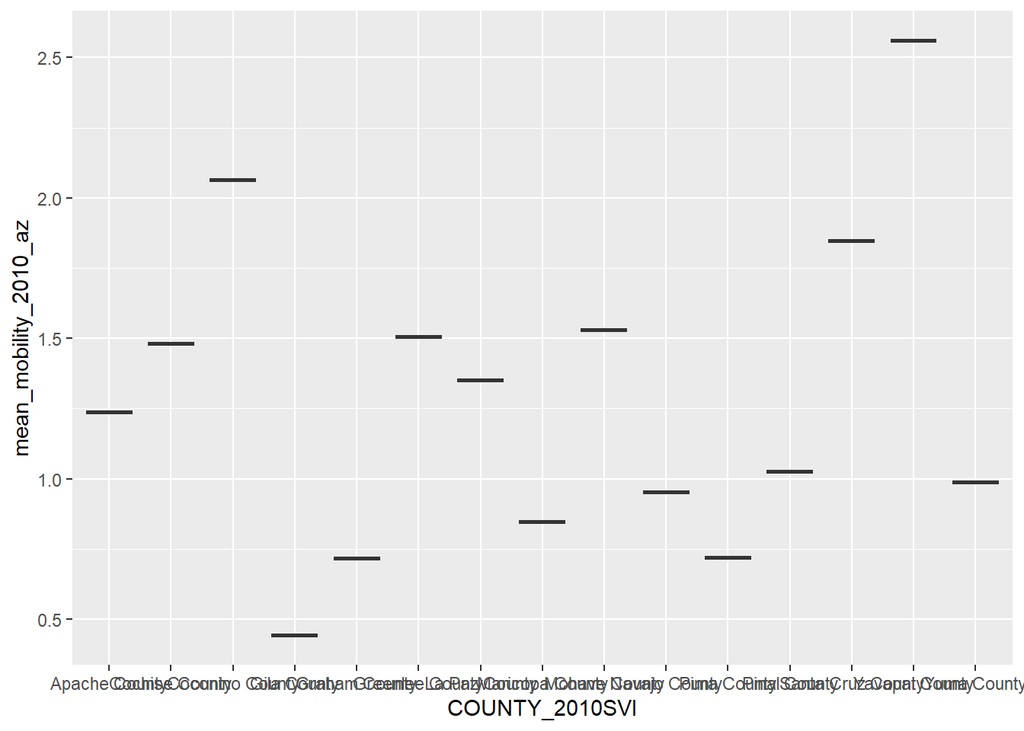

```r
mobility_plot <- ggplot(data = summary_stats_upward_2010,
                        mapping = aes(x= COUNTY_2010SVI, y=mean_mobility_2010_az)) +
  geom_boxplot()
print(mobility_plot)
```

Boxplots are great for comparing values across **categories** (like counties).  
However, with even 15 counties, the plot may start to look a bit crowded.

### State and County Summary

What if we want to summarize **every county in every state**?

```r
summary_stats_upward_2010_all <- merged_data %>%
  group_by(STATE_ABBR_2010SVI, COUNTY_2010SVI) %>%
  summarize(mean_mobility_2010 = mean(upward_mobility_rate_2010),
            sd_mobility_2010 = sd(upward_mobility_rate_2010))
```

Let’s now use this expanded dataset to create a boxplot, this time grouped by **state**:

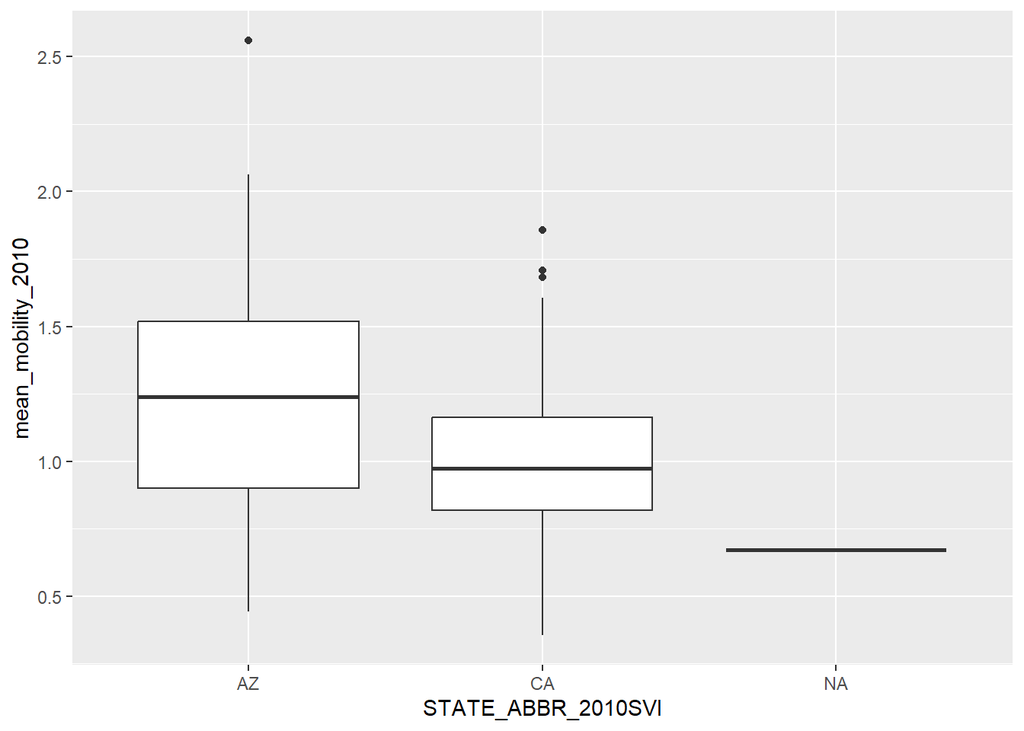

```r
mobility_plot <- ggplot(data = summary_stats_upward_2010_all,
                        mapping = aes(x = STATE_ABBR_2010SVI, y = mean_mobility_2010)) +
  geom_boxplot()
print(mobility_plot)
```

Sometimes, we might think a particular question or visualization is the most interesting way to look at our data — only to realize later that we need a **different perspective** or lens to truly understand it.

In data analysis, **being flexible and open to new approaches** is often more valuable than trying to be “right” on the first try (and, honestly, what does “right” even mean?).

Let’s take a closer look at the code we use to create graphs with `ggplot2`.

The main function for plotting is `ggplot()`. It requires two key pieces of information:

1. **Data** — which dataset we want to visualize.
2. **Mapping** — how to map variables in our data to the axes and other visual properties (like color or shape).

In our example, we want to plot a `boxplot`, so we specify the type of plot with `geom_boxplot()`.

Finally, we print the graph to the console with the `print()` command, or simply by typing the variable name that stores the plot.

We also often save the plot to a variable (e.g., `mobility_plot`) so we can reuse or modify it easily.

We have missing states, let’s remove that:

```r
summary_stats_upward_2010_all <- summary_stats_upward_2010_all[!is.na(summary_stats_upward_2010_all$STATE_ABBR_2010SVI),]
```

Let’s now use this expanded dataset to create a boxplot, this time grouped by **state**:

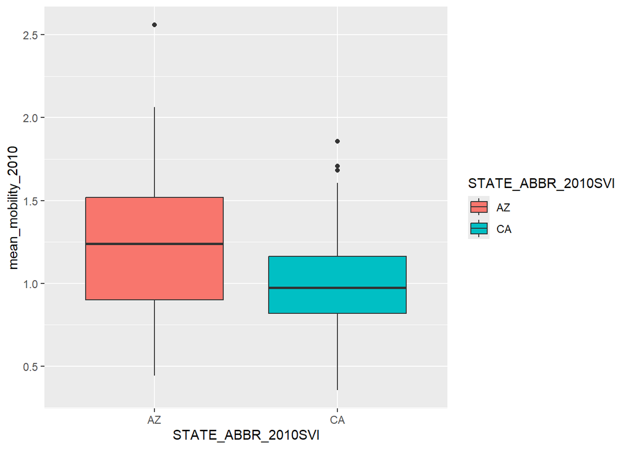

```r
mobility_plot <- ggplot(data = summary_stats_upward_2010_all,
                        mapping = aes(x= STATE_ABBR_2010SVI, y=mean_mobility_2010,
                                      fill = STATE_ABBR_2010SVI)) +
  geom_boxplot()
print(mobility_plot)
```

Save the plot:

```r
ggsave(plot = mobility_plot, filename = "output/mobility-plot-2010.pdf")
```

# Review of Learning Objectives

✅ Understand the difference between files and objects  
✅ Modify data with data hygiene principles  
✅ Summarize information from raw data  
✅ Visualize data to convey information

In our next lesson, we will build on these skills and begin working with **scientific computing** concepts.

## Student Activities

Follow these tasks using the skills from Lesson 1.

### 1. Explore a different county from AZ or CA

- Choose one county from Arizona or California, do not choose Pima County or Del Norte County
- Calculate the **mean** and **standard deviation** of `upward_mobility_rate_2010` and `upward_mobility_rate_2020`.
- Compare your results with the average of the state selected

Use the following code to see which counties are included in the Arizona and California subsets:

```r
# List counties in Arizona
table(subset_data_az$COUNTY_2010SVI)
```

```
##
##     Apache County    Cochise County   Coconino County       Gila County
##                16                32                28                16
##     Graham County   Greenlee County     La Paz County   Maricopa County
##                 9                 3                 9               916
##     Mohave County     Navajo County       Pima County      Pinal County
##                43                31               241                75
## Santa Cruz County    Yavapai County       Yuma County
##                10                42                55
```

```r
# List counties in California
table(subset_data_ca$COUNTY_2010SVI)
```

```
##
##         Alameda County          Alpine County          Amador County
##                    361                      1                      9
##           Butte County       Calaveras County          Colusa County
##                     51                     10                      5
##    Contra Costa County       Del Norte County       El Dorado County
##                    207                      7                     43
##          Fresno County           Glenn County        Humboldt County
##                    199                      6                     30
##        Imperial County            Inyo County            Kern County
##                     31                      6                    151
##           Kings County            Lake County          Lassen County
##                     27                     15                      9
##     Los Angeles County          Madera County           Marin County
##                   2345                     23                     56
##        Mariposa County       Mendocino County          Merced County
##                      6                     21                     49
##           Modoc County            Mono County        Monterey County
##                      4                      3                     94
##            Napa County          Nevada County          Orange County
##                     40                     20                    582
##          Placer County          Plumas County       Riverside County
##                     85                      7                    453
##      Sacramento County      San Benito County  San Bernardino County
##                    317                     11                    369
##       San Diego County   San Francisco County     San Joaquin County
##                    628                    196                    139
## San Luis Obispo County       San Mateo County   Santa Barbara County
##                     53                    158                     90
##     Santa Clara County      Santa Cruz County          Shasta County
##                    372                     52                     48
##          Sierra County        Siskiyou County          Solano County
##                      1                     14                     96
##          Sonoma County      Stanislaus County          Sutter County
##                     99                     94                     21
##          Tehama County         Trinity County          Tulare County
##                     11                      5                     78
##        Tuolumne County         Ventura County            Yolo County
##                     11                    174                     41
##            Yuba County
##                     14
```

### 2. Boxplot Selected County

- Using the county you chose in Task 1, create two boxplots using `ggplot2`:
  - One for `upward_mobility_rate_2010`
  - One for `upward_mobility_rate_2020`
- Compare the distributions between the two years.
- Are there any outliers?
- Save the plot

### 3. Filter Challenge

- Using the **state dataset** (either `subset_data_az` or `subset_data_ca`), filter the data to **only include rows where `upward_mobility_rate_2010` is greater than 1**.
- How many rows meet that condition?
- Do you notice any patterns in which counties appear?

You’ll need to “pipe” (%>%) your dataset into this function and provide the condition inside. To count the number of rows, try using nrow() after the filtering step.

### 4. Reflect and Extend

Take a moment to think beyond the instructions.

1. What question would *you* design based on this lesson? *(e.g., “Is mobility higher in counties with lower poverty rates?”)*
2. What questions do you still have?  
   *(What was confusing? What would you like to dive deeper into next time?)*